# Practical Machine Learning Course Project

Bamini Balaji

June 18, 2017

## Background

People regularly quantify how much of a particular activity they do, but they rarely quantify how well they do it. The goal of this project is to use data from accelerometers on the belt, forearm, arm, and dumbell of 6 participants to predict the manner in which they did the exercise.

## Getting and Cleaning Data

The raw data for the [training set](https://d396qusza40orc.cloudfront.net/predmachlearn/pml-training.csv) and [testing set](https://d396qusza40orc.cloudfront.net/predmachlearn/pml-testing.csv) have been imported as variables train_data and test_data such that values “#DIV/0!” were coerced to NA.

Let’s remove columns containing NA values and ensure that training data set has the same column classes testing data set.

#### Removing columns with NA

```r
train_data <- train_data[(sapply(train_data, function(x) !any(is.na(x))))]
test_data <- test_data[(sapply(test_data, function(x) !any(is.na(x))))]
```

#### Removing ID, timestamp and window columns in the training and testing data sets.

```r
train_data <- train_data[,c(2, 8:60)]
test_data <- test_data[,c(2, 8:59)]
```

#### Matching variable classes between training and testing data sets

```r
wrongclass <- which(sapply(train_data[, 1:53], class) != sapply(test_data[, 1:53], class))
sapply(wrongclass, function(x) class(train_data[,x]))
```

```
## magnet_dumbbell_z  magnet_forearm_y  magnet_forearm_z
##         "numeric"         "numeric"         "numeric"
```

```r
sapply(wrongclass, function(x) class(test_data[,x]))
```

```
## magnet_dumbbell_z  magnet_forearm_y  magnet_forearm_z
##         "integer"         "integer"         "integer"
```

```r
test_data[, wrongclass] <- sapply(wrongclass, function(y) as.numeric(test_data[, y]))
```

40, 52, 53 are the columns where there was a mismatch in the classes between train_data (numeric) and test_data (integer). These columns were converted to the numeric class for test_data.

The training data contains 19622 rows and 54 variables while the testing data contains 20 rows and 53 variables. Let’s divide the train_data into a training set and a validation set.

```r
set.seed(123987)
inTrain <- createDataPartition(y = train_data$classe, p = 0.8, list = FALSE)
training <- train_data[inTrain, ]
validation <- train_data[-inTrain, ]
```

## Model

Let’s build a few models using various methods: trees, bagging, random forests and support vector machines.

```r
set.seed(212)
fit_trees <- train(classe ~ ., method = "rpart", data = training)
fit_bagging <- train(classe ~., method = "treebag", data = training)
fit_rf <- randomForest(classe ~., data = training)
fit_svm <- svm(classe ~., data = training)
```

The following figure shows the decision tree generated with the tree based model.

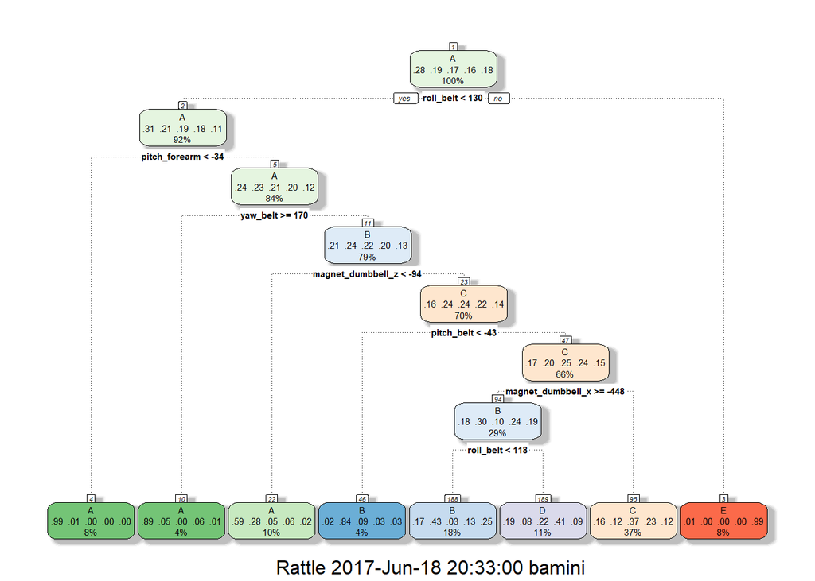

## Cross Validation and Model selection

Now let’s evaluate the accuracy of these models at determining type of activity for the validation set.

```r
CM_trees <- confusionMatrix(validation$classe, predict(fit_trees, validation))
CM_bagging <- confusionMatrix(validation$classe, predict(fit_bagging, validation))
CM_rf <- confusionMatrix(validation$classe, predict(fit_rf, validation))
CM_svm <- confusionMatrix(validation$classe, predict(fit_svm, validation))

# Calculate model accuracies
sapply(list(trees = CM_trees, bagging = CM_bagging, RF = CM_rf, SVM = CM_svm), function(x) x$overall["Accuracy"])
```

```
##   trees.Accuracy bagging.Accuracy      RF.Accuracy     SVM.Accuracy
##        0.5559521        0.9898037        0.9956666        0.9434107
```

```r
CM_rf
```

```
## Confusion Matrix and Statistics
##
##           Reference
## Prediction    A    B    C    D    E
##          A 1116    0    0    0    0
##          B    0  758    1    0    0
##          C    0    4  680    0    0
##          D    0    0    8  634    1
##          E    0    0    1    2  718
##
## Overall Statistics
##
##                Accuracy : 0.9957
##                  95% CI : (0.9931, 0.9975)
##     No Information Rate : 0.2845
##     P-Value [Acc > NIR] : < 2.2e-16
##
##                   Kappa : 0.9945
##  Mcnemar's Test P-Value : NA
##
## Statistics by Class:
##
##                      Class: A Class: B Class: C Class: D Class: E
## Sensitivity            1.0000   0.9948   0.9855   0.9969   0.9986
## Specificity            1.0000   0.9997   0.9988   0.9973   0.9991
## Pos Pred Value         1.0000   0.9987   0.9942   0.9860   0.9958
## Neg Pred Value         1.0000   0.9987   0.9969   0.9994   0.9997
## Prevalence             0.2845   0.1942   0.1759   0.1621   0.1833
## Detection Rate         0.2845   0.1932   0.1733   0.1616   0.1830
## Detection Prevalence   0.2845   0.1935   0.1744   0.1639   0.1838
## Balanced Accuracy      1.0000   0.9972   0.9921   0.9971   0.9988
```

```r
CM_bagging
```

```
## Confusion Matrix and Statistics
##
##           Reference
## Prediction    A    B    C    D    E
##          A 1109    2    5    0    0
##          B    3  751    5    0    0
##          C    1    4  676    3    0
##          D    0    2   10  631    0
##          E    0    0    3    2  716
##
## Overall Statistics
##
##                Accuracy : 0.9898
##                  95% CI : (0.9861, 0.9927)
##     No Information Rate : 0.2837
##     P-Value [Acc > NIR] : < 2.2e-16
##
##                   Kappa : 0.9871
##  Mcnemar's Test P-Value : NA
##
## Statistics by Class:
##
##                      Class: A Class: B Class: C Class: D Class: E
## Sensitivity            0.9964   0.9895   0.9671   0.9921   1.0000
## Specificity            0.9975   0.9975   0.9975   0.9963   0.9984
## Pos Pred Value         0.9937   0.9895   0.9883   0.9813   0.9931
## Neg Pred Value         0.9986   0.9975   0.9929   0.9985   1.0000
## Prevalence             0.2837   0.1935   0.1782   0.1621   0.1825
## Detection Rate         0.2827   0.1914   0.1723   0.1608   0.1825
## Detection Prevalence   0.2845   0.1935   0.1744   0.1639   0.1838
## Balanced Accuracy      0.9970   0.9935   0.9823   0.9942   0.9992
```

This shows that the random forest model and bagging model have greatest accuracy.

## Prediction

Below are the predictions for activity classification of the test_data using the random forest model and bagging model.

```r
predict(fit_rf, test_data)
```

```
##  1  2  3  4  5  6  7  8  9 10 11 12 13 14 15 16 17 18 19 20
##  B  A  B  A  A  E  D  B  A  A  B  C  B  A  E  E  A  B  B  B
## Levels: A B C D E
```

```r
predict(fit_bagging, test_data)
```

```
##  [1] B A B A A E D B A A B C B A E E A B B B
## Levels: A B C D E
```